# Выбор модели для классификации пользователей TripAdvisor

Alexey Shovkun

Tuesday, April 18, 2015

## Разведка исходных даных

Выделяем обучающую и тестовую выборки. Проверку качества модели в процессе подбора её параметров будем делать с использованием метода перекрестной проверки (cross validation) на обучающей выборке. Тестовая выборка будет использована **только** для оценки качества результирующей модели.

Размеры выборок:

- обучающая: 28 экземпляров.
- проверочная: отсутствует.
- тестовая: 12 экземпляров.

## Малоинформативные параметры

Проанализируем, какие параметры не несут информации (вариация равна 0, все значения одинаковы) или почти не несут информации (вариация близка к 0, большинство значений параметра одинаковы).

```
##                                                            freqRatio
## tagFashion                                                         0
## tagTourist                                                         0
## tagSenior                                                          0
## hotelReviewed_Adaaran_Prestige_Ocean_Villas                        0
## hotelReviewed_Adaaran_Prestige_Vadoo                               0
## hotelReviewed_Adaaran_Select_Hudhuranfushi                         0
## hotelReviewed_Adaaran_Select_Meedhupparu                           0
## hotelReviewed_Anantara_Veli_Resort_AND_Spa                         0
## hotelReviewed_Angaga_Island_Resort                                 0
## hotelReviewed_Angsana_Velavaru                                     0
## hotelReviewed_Asdu_Sun_Island                                      0
## hotelReviewed_Atmosphere_Kanifushi_Maldives                        0
## hotelReviewed_Ayada_Maldives                                       0
## hotelReviewed_Banyan_Tree_Vabbinfaru                               0
## hotelReviewed_Baros_Maldives                                       0
## hotelReviewed_Biyadhoo_Island_Resort                               0
## hotelReviewed_Centara_Grand_Island_Resort_AND_Spa_Maldives         0
## hotelReviewed_Centara_Ras_Fushi_Resort_AND_Spa                     0
## hotelReviewed_Chaaya_Island_Dhonveli                               0
## hotelReviewed_Chaaya_Lagoon_Hakuraa_Huraa                          0
## hotelReviewed_Chaaya_Reef_Ellaidhoo                                0
## hotelReviewed_Club_Faru                                            0
## hotelReviewed_Club_Med_Kani                                        0
## hotelReviewed_Coco_Bodu_Hithi                                      0
## hotelReviewed_Coco_Palm_Dhuni_Kolhu                                0
## hotelReviewed_Cocoa_Island_by_COMO                                 0
## hotelReviewed_Conrad_Maldives_Rangali_Island                       0
## hotelReviewed_Constance_Halaveli                                   0
## hotelReviewed_Constance_Moofushi                                   0
## hotelReviewed_Diamonds_Thudufushi                                  0
## hotelReviewed_Dusit_Thani_Maldives                                 0
## hotelReviewed_Embudu_Village                                       0
## hotelReviewed_Equator_Village                                      0
## hotelReviewed_Eriyadu_Island_Resort                                0
## hotelReviewed_Fern_Boquete_Inn                                     0
## hotelReviewed_Fihalhohi_Tourist_Resort                             0
## hotelReviewed_Filitheyo_Island_Resort                              0
## hotelReviewed_Fun_Island_Resort                                    0
## hotelReviewed_Gangehi_Island_Resort                                0
```

[output cut: 224 more lines]

```
## hotelReviewed_Safari_Island                                   TRUE TRUE
## hotelReviewed_Sheraton_Maldives_Full_Moon_Resort_AND_Spa      TRUE TRUE
## hotelReviewed_Skai_Lodge                                      TRUE TRUE
## hotelReviewed_Soneva_Fushi_Resort                             TRUE TRUE
## hotelReviewed_Summer_Island_Village                           TRUE TRUE
## hotelReviewed_Taj_Exotica_Resort_AND_Spa                      TRUE TRUE
## hotelReviewed_The_Boutique_Inn_at_Villa_Shabnamee             TRUE TRUE
## hotelReviewed_The_Residence_Maldives                          TRUE TRUE
## hotelReviewed_The_Sun_Siyam_Iru_Fushi_Maldives                TRUE TRUE
## hotelReviewed_Velaa_Private_Island                            TRUE TRUE
## hotelReviewed_Velidhu_Island_Resort                           TRUE TRUE
## hotelReviewed_Veligandu_Island_Resort_AND_Spa                 TRUE TRUE
## hotelReviewed_Viceroy_Maldives                                TRUE TRUE
## hotelReviewed_VOI_Dhiggiri_Resort                             TRUE TRUE
## hotelReviewed_W_Retreat_AND_Spa_Maldives                      TRUE TRUE
```

Перечисленные выше параметры не могут быть использованы для обучения модели. При сборе большего количества обучающих примеров, следует рассмотреть пользователей, у которых эти параметры не равны 0.

## Обучение модели

### Форсированная логистическая регрессия (Boosted Logistic Regression)

```
## Boosted Logistic Regression
##
## 28 samples
## 35 predictors
##  2 classes: '0', '1'
##
## No pre-processing
## Resampling: Cross-Validated (10 fold)
##
## Summary of sample sizes: 26, 26, 25, 25, 25, 25, ...
##
## Resampling results across tuning parameters:
##
##   nIter  Accuracy   Kappa      Accuracy SD  Kappa SD
##    20    0.6666667  0.2777778  0.2939724    0.5651942
##    30    0.6666667  0.3111111  0.3424674    0.6565905
##    40    0.7000000  0.4300000  0.2810913    0.5498485
##    45    0.6333333  0.2800000  0.2810913    0.5808040
##    50    0.6333333  0.2800000  0.2810913    0.5808040
##    53    0.7166667  0.4300000  0.2727319    0.5498485
##    55    0.7500000  0.4700000  0.2389535    0.5292552
##    57    0.7166667  0.4400000  0.3147603    0.5947922
##    60    0.7333333  0.3666667  0.2509242    0.5431390
##    65    0.7166667  0.4300000  0.2727319    0.5498485
##    70    0.7000000  0.3800000  0.3220306    0.6562520
##    90    0.7000000  0.3800000  0.3220306    0.6562520
##   100    0.7333333  0.3666667  0.2509242    0.5431390
##   110    0.7333333  0.3666667  0.2509242    0.5431390
##   150    0.7166667  0.3555556  0.2727319    0.5960518
##   180    0.6333333  0.2700000  0.2330686    0.4715224
##   200    0.6666667  0.3300000  0.2605787    0.5250397
##   250    0.6000000  0.1700000  0.1956313    0.4001389
##   300    0.6083333  0.1800000  0.2005009    0.4077036
##   400    0.6083333  0.1800000  0.2005009    0.4077036
##   500    0.6083333  0.1800000  0.2005009    0.4077036
##
## Accuracy was used to select the optimal model using  the largest value.
## The final value used for the model was nIter = 55.
```

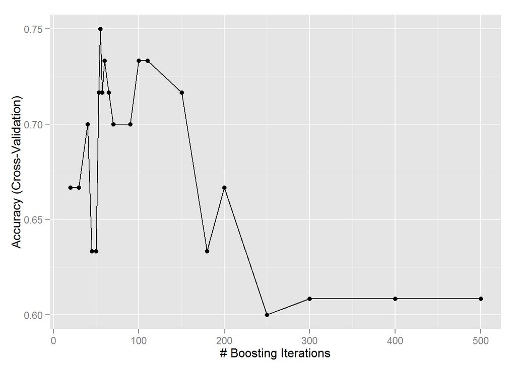

### Дерево решений (Decision Tree)

```
## CART
##
##  28 samples
## 145 predictors
##   2 classes: '0', '1'
##
## No pre-processing
## Resampling: Cross-Validated (10 fold)
##
## Summary of sample sizes: 26, 25, 25, 25, 26, 26, ...
##
## Resampling results across tuning parameters:
##
##   cp          Accuracy  Kappa  Accuracy SD  Kappa SD
##   0.00000000  0.4       -0.23  0.2509242    0.5478240
##   0.02255639  0.4       -0.23  0.2509242    0.5478240
##   0.04511278  0.4       -0.23  0.2509242    0.5478240
##   0.06766917  0.4       -0.23  0.2509242    0.5478240
##   0.09022556  0.4       -0.23  0.2509242    0.5478240
##   0.11278195  0.4       -0.23  0.2509242    0.5478240
##   0.13533835  0.4       -0.23  0.2509242    0.5478240
##   0.15789474  0.4       -0.23  0.2509242    0.5478240
##   0.18045113  0.4       -0.23  0.2509242    0.5478240
##   0.20300752  0.4       -0.23  0.2509242    0.5478240
##   0.22556391  0.4       -0.23  0.2509242    0.5478240
##   0.24812030  0.4       -0.23  0.2509242    0.5478240
##   0.27067669  0.4       -0.23  0.2509242    0.5478240
##   0.29323308  0.4       -0.23  0.2509242    0.5478240
##   0.31578947  0.4       -0.23  0.2509242    0.5478240
##   0.33834586  0.4       -0.23  0.2509242    0.5478240
##   0.36090226  0.4       -0.23  0.2509242    0.5478240
##   0.38345865  0.4       -0.23  0.2509242    0.5478240
##   0.40601504  0.4       -0.23  0.2509242    0.5478240
##   0.42857143  0.3       -0.35  0.1721326    0.4116363
##
## Accuracy was used to select the optimal model using  the largest value.
## The final value used for the model was cp = 0.406015.
```

```
## n= 28
##
## node), split, n, loss, yval, (yprob)
##       * denotes terminal node
##
## 1) root 28 14 0 (0.5000000 0.5000000)
##   2) CPYCount< 0.5839635 20  7 0 (0.6500000 0.3500000) *
##   3) CPYCount>=0.5839635 8  1 1 (0.1250000 0.8750000) *
```

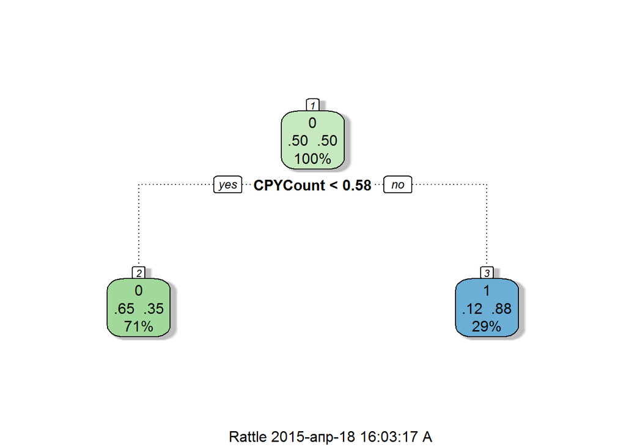

### Случайный лес (Random Forest)

```
## Random Forest
##
##  28 samples
## 145 predictors
##   2 classes: '0', '1'
##
## No pre-processing
## Resampling: Cross-Validated (10 fold)
##
## Summary of sample sizes: 26, 24, 25, 26, 25, 25, ...
##
## Resampling results across tuning parameters:
##
##   mtry        Accuracy   Kappa  Accuracy SD  Kappa SD
##     4.333333  0.5000000  0.03   0.3424674    0.6395311
##     6.500000  0.5583333  0.07   0.3094449    0.6092801
##    13.000000  0.5250000  0.04   0.3514740    0.6467010
##    26.000000  0.5583333  0.13   0.3470555    0.6254776
##    49.000000  0.5666667  0.11   0.3186585    0.6172520
##    73.000000  0.5333333  0.06   0.3244178    0.6467010
##    98.000000  0.5333333  0.06   0.3244178    0.6467010
##   146.000000  0.5666667  0.14   0.2772217    0.5738757
##
## Accuracy was used to select the optimal model using  the largest value.
## The final value used for the model was mtry = 49.
```

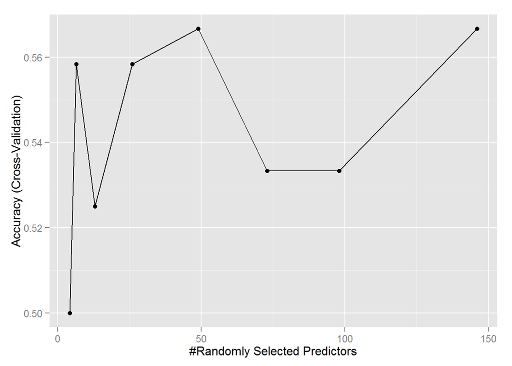

### Метод опорных векторов (Support Vector Machine)

```
## Support Vector Machines with Linear Kernel
##
## 28 samples
## 35 predictors
##  2 classes: '0', '1'
##
## No pre-processing
## Resampling: Cross-Validated (10 fold)
##
## Summary of sample sizes: 26, 24, 25, 26, 25, 25, ...
##
## Resampling results across tuning parameters:
##
##   C      Accuracy   Kappa          Accuracy SD  Kappa SD
##    0.03  0.4583333   5.000000e-02  0.2124591    0.3689324
##    0.10  0.5083333  -1.110223e-17  0.3153726    0.6236096
##    0.30  0.5333333   8.000000e-02  0.3291403    0.6460134
##    0.50  0.5833333   1.800000e-01  0.3191424    0.6232531
##    0.60  0.6083333   2.300000e-01  0.2993047    0.5812821
##    0.70  0.6083333   2.300000e-01  0.2993047    0.5812821
##    0.80  0.5833333   1.800000e-01  0.2965855    0.5769652
##    0.90  0.6083333   2.300000e-01  0.2993047    0.5812821
##    1.00  0.6083333   2.300000e-01  0.2993047    0.5812821
##    1.10  0.6416667   2.700000e-01  0.2834150    0.5774465
##    1.50  0.6416667   2.700000e-01  0.2834150    0.5774465
##    3.00  0.6416667   2.700000e-01  0.2834150    0.5774465
##   10.00  0.6416667   2.700000e-01  0.2834150    0.5774465
##   15.00  0.6416667   2.700000e-01  0.2834150    0.5774465
##
## Accuracy was used to select the optimal model using  the largest value.
## The final value used for the model was C = 1.1.
```

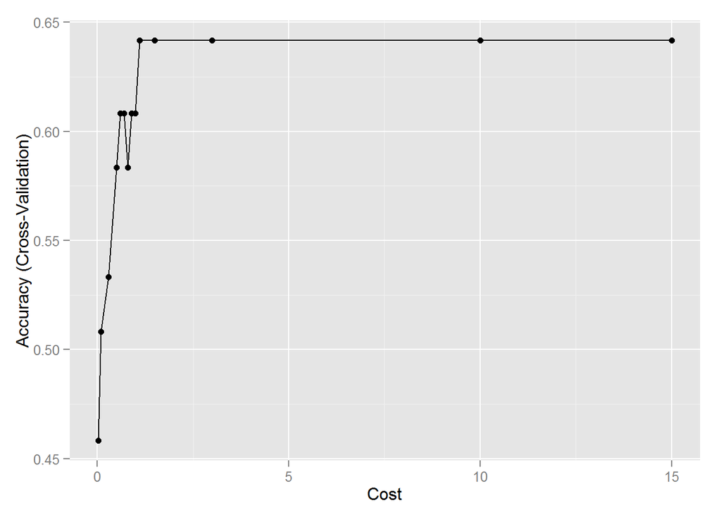

### Логистическая регрессия (Generalized Linear Model)

```
## Generalized Linear Model
##
## 28 samples
## 35 predictors
##  2 classes: '0', '1'
##
## No pre-processing
## Resampling: Cross-Validated (10 fold)
##
## Summary of sample sizes: 26, 26, 25, 25, 25, 25, ...
##
## Resampling results
##
##   Accuracy   Kappa  Accuracy SD  Kappa SD
##   0.4583333  -0.06  0.3952847    0.787683
##
##
```

### Boosted Generalized Linear Model

```
## Boosted Generalized Linear Model
##
## 28 samples
## 35 predictors
##  2 classes: '0', '1'
##
## No pre-processing
## Resampling: Cross-Validated (10 fold)
##
## Summary of sample sizes: 26, 26, 25, 25, 25, 25, ...
##
## Resampling results across tuning parameters:
##
##   mstop  Accuracy   Kappa          Accuracy SD  Kappa SD
##     50   0.5666667   1.300000e-01  0.3784308    0.7087548
##    100   0.6000000   1.600000e-01  0.3351801    0.6703233
##    150   0.5250000   1.000000e-02  0.3192632    0.6279597
##    200   0.5083333  -1.110223e-17  0.2734383    0.5228129
##    250   0.5416667   6.000000e-02  0.3124228    0.6022181
##    300   0.5416667   6.000000e-02  0.3124228    0.6022181
##    350   0.5416667   6.000000e-02  0.3124228    0.6022181
##    400   0.5416667   6.000000e-02  0.3124228    0.6022181
##    450   0.5750000   9.000000e-02  0.2619078    0.5606544
##    500   0.5750000   9.000000e-02  0.2619078    0.5606544
##    550   0.5750000   9.000000e-02  0.2619078    0.5606544
##    600   0.5750000   9.000000e-02  0.2619078    0.5606544
##    650   0.5750000   9.000000e-02  0.2619078    0.5606544
##    700   0.5750000   9.000000e-02  0.2619078    0.5606544
##    750   0.5750000   9.000000e-02  0.2619078    0.5606544
##    800   0.5750000   9.000000e-02  0.2619078    0.5606544
##    850   0.5750000   9.000000e-02  0.2619078    0.5606544
##    900   0.5750000   9.000000e-02  0.2619078    0.5606544
##    950   0.5750000   9.000000e-02  0.2619078    0.5606544
##   1000   0.5750000   9.000000e-02  0.2619078    0.5606544
##
## Tuning parameter 'prune' was held constant at a value of no
## Accuracy was used to select the optimal model using  the largest value.
## The final values used for the model were mstop = 100 and prune = no.
```

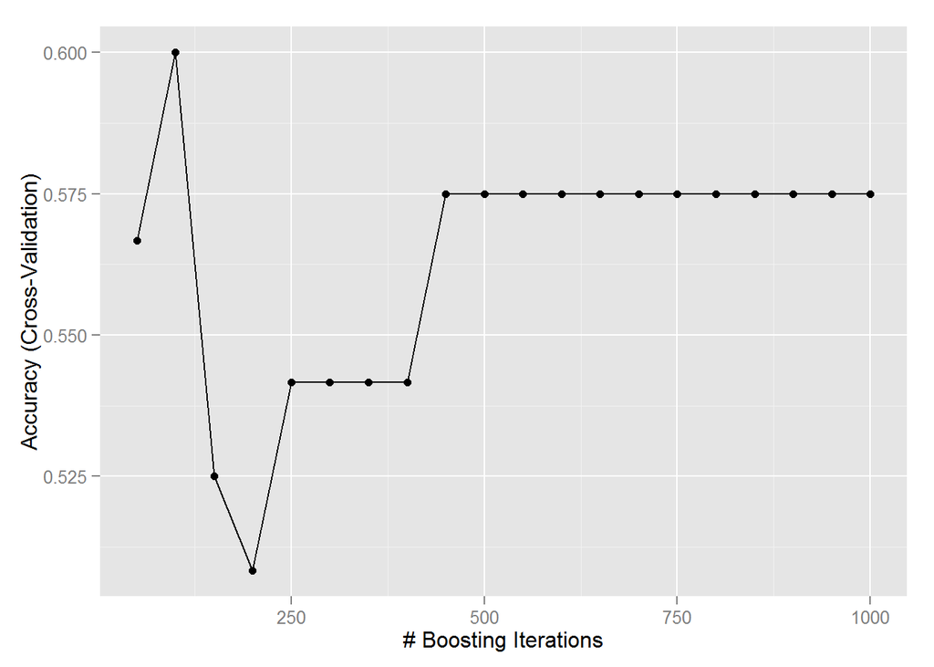

### Generalized Linear Model with Stepwise Feature Selection

Работает очень медленно. За 20 минут нет результата.

### Анализ качества обученных моделей

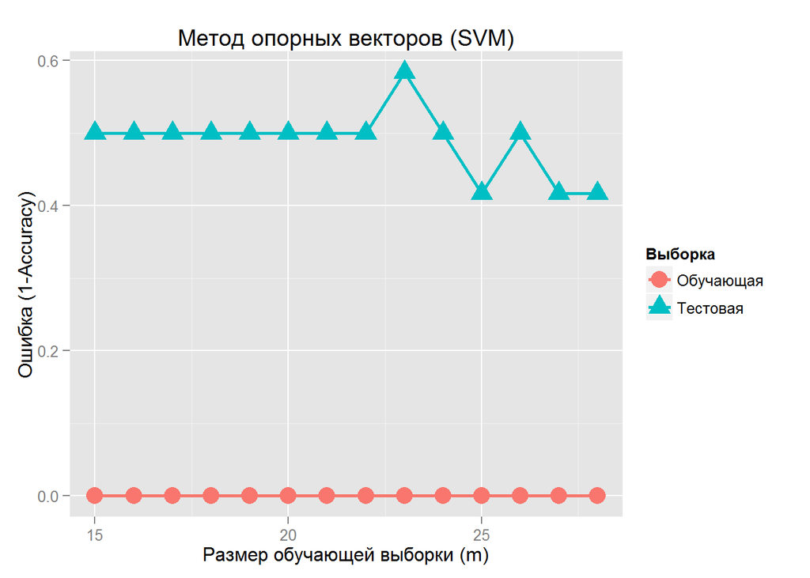

Проведем анализ сдвига/разброса на основе Логистической регрессии c параметром nIter =55.

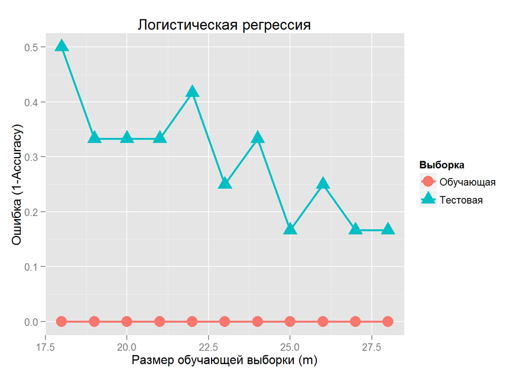

Выводы аналогичны выводам, сделанным для метода опорных векторов, однако, здесь ошибка на тестовой выборке уменьшается быстрее, что означает, что, скорее всего, для логистической регрессии понадобится меньгая обучающая выборка для того, чтобы она перестала быть переобученной (overfitted).

## Классификация новых пользователей (предсказание)

Предскажем категорию Интересен/не интересен для ранее не рассмотренных пользователей. Используем модель на основе логистической регрессии, которая показала наивысшую точность **~75%**. Результат экспортируем в Excel файл для дальнейшего анализа и использования.

```
##
##   0   1
## 703 333
```

## Оценка качества предсказания на новых данных

Предсказанные классы данных были показаны эксперту и по ним получено его мнение. Оценим точность предсказания.

```
## Confusion Matrix and Statistics
##
##           Reference
## Prediction  0  1
##          0 30 12
##          1  7 18
##
##                Accuracy : 0.7164
##                  95% CI : (0.5931, 0.8199)
##     No Information Rate : 0.5522
##     P-Value [Acc > NIR] : 0.004333
##
##                   Kappa : 0.4174
##  Mcnemar's Test P-Value : 0.358795
##
##             Sensitivity : 0.8108
##             Specificity : 0.6000
##          Pos Pred Value : 0.7143
##          Neg Pred Value : 0.7200
##              Prevalence : 0.5522
##          Detection Rate : 0.4478
##    Detection Prevalence : 0.6269
##       Balanced Accuracy : 0.7054
##
##        'Positive' Class : 0
##
```

Видим, что точность предсказания составляет порядка 71,6%, при этом система лучше предсказывает “не интересных” клиентов и чаще ошибается, считая “интересных” клиентов не интересными.

### Выводы

Необходимо продолжить обучение модели. Направления дальнейших исследований:

1. Повторить выбор алгоритма классификации с учетом расширенного набора тестовых примеров.
2. Изменить параметры, используемые для анализа пользователей TripAdvisor:
   - Скачать информацию обо всех отелях и ресторанах, посещенных пользователем.
   - Сформиировать списки VIP и “не VIP” мест (отелей и ресторанов).
   - Вместо категорийных параметров был/не был в отеле использовать параметры “Количество посещенных VIP мест” и “Количество посещенных не-VIP мест”
3. Повторить выбор алгоритма классификации с учетом сокращенного набора параметров пользователя.